# Block-bootstrap scenarios of real returns

```julia
# Defaults for running the cells outside Quarto. Under `quarto render` the front-matter
# `params` (overridden by `-P name:value` or `--execute-params file.yml`, see
# render_bb_reports.sh) are already defined as constants, so these assignments are skipped.
@isdefined(cma) || (cma = Dict("r" => 0.005, "rb_real" => 0.015, "re_real" => 0.045))
@isdefined(period) || (period = [1935, 2025])   # historical sample bootstrapped
@isdefined(block_size) || (block_size = 5)      # (mean) block length in years
@isdefined(random_block) || (random_block = true)  # stationary bootstrap
@isdefined(T) || (T = 100)                      # simulated years
@isdefined(horizons) || (horizons = [1, 5, 10, 20, 30, 50, 100])  # horizon table years, ≤ T
@isdefined(n_scen) || (n_scen = 10000)
@isdefined(seed) || (seed = 1234)
```

```julia
import Pkg
Pkg.activate(joinpath(@__DIR__, "..", ".."); io = devnull)

using MacroFinanceScenarios
using MacroFinanceScenarios.IbbotsonSinquefield
using MacroFinanceScenarios.EDA
using MacroFinanceScenarios.ScenariosEvaluation
using CSV, DataFrames, Random, Statistics, TimeSeries
using Plots

show_table(t; title = "", digits = 2) =
    display(HTML(sprint(io -> print_table(io, t; backend = :html, digits, title))))

# Everything loaded and computed is in decimal log units; the report shows percent. Means,
# std and percentiles scale by 100; skewness, kurtosis, autocorrelations and correlations
# do not, and `neg` (share of negative values) is already in percent.
pct(sc::Scenarios) = Scenarios(100 .* sc.data, sc.names, sc.start_year)
function pct(df::DataFrame; cols)
    out = copy(df)
    for c in cols
        out[!, c] = 100 .* out[!, c]
    end
    return out
end
moment_cols = [:mean, :std, :min, :p25, :p50, :p75, :max]   # describe_series columns in %
span(p) = "$(p[1])–$(p[2])"

vars = [:r, :rb_real, :re_real]
# Quarto passes the `cma` mapping as a Dict{String}; match_means takes a NamedTuple and
# rejects unknown names.
targets = (; (Symbol(k) => Float64(v) for (k, v) in cma)...)
```

## Data and assumptions

Annual real returns from `data/shiller_annual.csv` (written by `export_shiller_annual.jl`): the real T-bill return `r`, the real bond return `rb_real` and the real equity return `re_real`, 1935–2025. Each variable is shifted by a constant so that its sample mean equals the capital market assumption (CMA); std, skewness, autocorrelation and correlations are unchanged. The CMA are means of annual **log** returns: a simple expected return `E[R]` corresponds to roughly `log(1 + E[R]) − σ²/2`.

```julia
raw = TimeArray(CSV.File(joinpath(@__DIR__, "..", "..", "data", "shiller_annual.csv"));
                timestamp = :timestamp)
data = subperiod(raw[vars...], (period[1], period[2]))
hist = match_means(data, targets)

show_table(DataFrame(variable = String.(vars),
                     historical_mean = [100mean(values(data[v])) for v in vars],
                     cma_target = [100get(targets, v, mean(values(data[v]))) for v in vars],
                     shift = [100(mean(values(hist[v])) - mean(values(data[v]))) for v in vars]);
           title = "Means of annual log real returns (%)")
show_table(DataFrame(parameter = ["sample", "years", "block size", "block lengths",
                                  "simulated years", "scenarios", "seed"],
                     value = [span(period), string(length(hist)), string(block_size),
                              random_block ? "random (stationary bootstrap)" : "fixed",
                              string(T), string(n_scen), string(seed)]);
           title = "Parameters")
```

| Means of annual log real returns (%) variable String | Means of annual log real returns (%) historical_mean Float64 | Means of annual log real returns (%) cma_target Float64 | Means of annual log real returns (%) shift Float64 |
| --- | --- | --- | --- |
| r | -0.14 | 0.5 | 0.64 |
| rb_real | 1.0 | 1.5 | 0.5 |
| re_real | 7.06 | 5.5 | -1.56 |

| Parameters parameter String | Parameters value String |
| --- | --- |
| sample | 1935–2025 |
| years | 91 |
| block size | 5 |
| block lengths | random (stationary bootstrap) |
| simulated years | 100 |
| scenarios | 10000 |
| seed | 1234 |

Units: returns and moments below are annual log values in percent, except where a table or chart says *simple rate* (`exp(·) − 1` of the log rate, in percent) or *wealth* (of 1 invested); skewness, excess kurtosis, autocorrelations and correlations are unit-free.

## Historical moments

The matched sample that is bootstrapped (means = CMA targets).

```julia
hist_moments = describe_series(hist)
hist_cor = correlation_table(hist)
hist_pct = pct(hist_moments; cols = moment_cols)
show_table(hist_pct; title = "Matched sample, $(span(period))")
show_table(hist_cor; title = "Correlations, $(span(period))")
```

| Matched sample, 1935–2025 variable String | Matched sample, 1935–2025 mean Float64 | Matched sample, 1935–2025 std Float64 | Matched sample, 1935–2025 skewness Float64 | Matched sample, 1935–2025 ex_kurtosis Float64 | Matched sample, 1935–2025 ar1 Float64 | Matched sample, 1935–2025 neg Float64 | Matched sample, 1935–2025 min Float64 | Matched sample, 1935–2025 p5 Float64 | Matched sample, 1935–2025 p25 Float64 | Matched sample, 1935–2025 p50 Float64 | Matched sample, 1935–2025 p75 Float64 | Matched sample, 1935–2025 p95 Float64 | Matched sample, 1935–2025 max Float64 |
| --- | --- | --- | --- | --- | --- | --- | --- | --- | --- | --- | --- | --- | --- |
| r | 0.5 | 3.46 | -1.5 | 4.56 | 0.55 | 37.36 | -15.65 | -0.06 | -1.13 | 1.09 | 2.38 | 0.05 | 7.18 |
| rb_real | 1.5 | 8.03 | 0.11 | 0.56 | 0.1 | 39.56 | -21.92 | -0.1 | -3.19 | 1.46 | 5.75 | 0.14 | 24.44 |
| re_real | 5.5 | 17.29 | -0.96 | 0.83 | -0.02 | 31.87 | -50.67 | -0.27 | -3.6 | 9.89 | 16.44 | 0.28 | 37.56 |

| Correlations, 1935–2025 variable String | Correlations, 1935–2025 r Float64 | Correlations, 1935–2025 rb_real Float64 | Correlations, 1935–2025 re_real Float64 |
| --- | --- | --- | --- |
| r | 1.0 | 0.64 | 0.28 |
| rb_real | 0.64 | 1.0 | 0.18 |
| re_real | 0.28 | 0.18 | 1.0 |

## Simulation

Each simulated year is one whole historical year (so its cross-sectional correlation is kept), drawn in blocks of consecutive years (keeping autocorrelation up to the block length). Blocks are circular — they wrap from the last year to the first — so every year is drawn with the same probability and the simulated mean equals the CMA target in expectation. No moment matching is applied after the simulation: the gap between the achieved mean and the target is bootstrap noise, summarised by its standard error (std of the per-path means / √n_scen).

```julia
sc = block_bootstrap(hist, T, n_scen; block_size, random_block, rng = MersenneTwister(seed))
path_means = dropdims(mean(sc.data; dims = 2); dims = 2)   # n_vars × n_scen
achieved = DataFrame(variable = String.(sc.names),
                     target = [100mean(values(hist[v])) for v in sc.names],
                     simulated = 100vec(mean(path_means; dims = 2)),
                     se = 100vec(std(path_means; dims = 2)) ./ sqrt(n_scen))
achieved.z = (achieved.simulated .- achieved.target) ./ achieved.se
show_table(achieved; title = "Mean over all years and paths vs. target (%)")
println("Simulated years $(first(scenario_years(sc)))–$(last(scenario_years(sc))).")
```

```
Simulated years 2026–2125.
```

| Mean over all years and paths vs. target (%) variable String | Mean over all years and paths vs. target (%) target Float64 | Mean over all years and paths vs. target (%) simulated Float64 | Mean over all years and paths vs. target (%) se Float64 | Mean over all years and paths vs. target (%) z Float64 |
| --- | --- | --- | --- | --- |
| r | 0.5 | 0.5 | 0.01 | 0.84 |
| rb_real | 1.5 | 1.51 | 0.01 | 0.66 |
| re_real | 5.5 | 5.5 | 0.02 | 0.09 |

## Fan charts

5–95 and 25–75 percentile bands, median, and the CMA target (dashed).

```julia
μ_target = Dict(v => mean(values(hist[v])) for v in vars)
fans(vars; kwargs...) = [fan(sc, v; μ = μ_target[v], μ_label = "CMA target", kwargs...) for v in vars]
```

```
fans (generic function with 1 method)
```

### Cumulative wealth

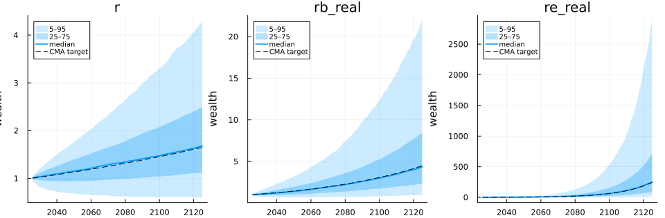

Wealth of 1 invested, real

```julia
plot(fans(vars; kind = :wealth)...; layout = (1, 3), size = (1000, 330), ylabel = "wealth")
```

### Annualised returns

Geometric-average annual return over the first `h` years, `exp(sum(x_1..h)/h) − 1`.

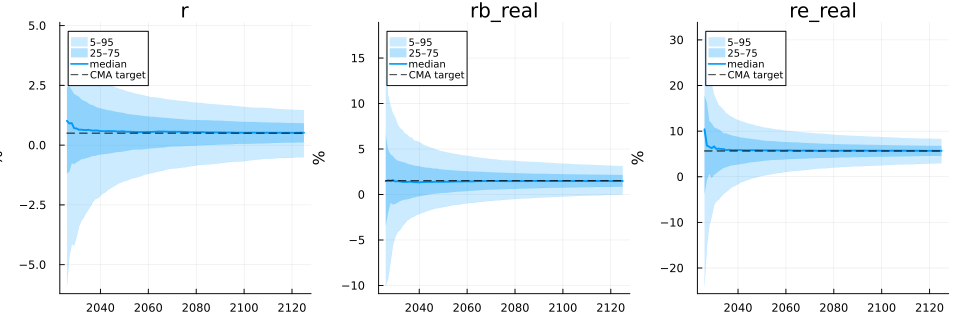

Annualised simple real rates

```julia
plot(fans(vars; kind = :annualised, simple = true, scale = 100)...;
     layout = (1, 3), size = (1000, 330), ylabel = "%")
```

## Evaluation

### Per-path moments

Statistics computed within each simulated path, then summarised across scenarios; the `historical` column is the matched sample. `neg` is the percent of years with a negative value. Autocorrelation beyond a block is lost, so with a small `block_size` the within-path `ar1` is biased towards 0 relative to history.

```julia
for (name, t) in path_moments(pct(sc); hist = hist_pct)
    show_table(t; title = String(name))
end
```

| r statistic String | r historical Float64 | r mean Float64 | r p5 Float64 | r p25 Float64 | r p50 Float64 | r p75 Float64 | r p95 Float64 |
| --- | --- | --- | --- | --- | --- | --- | --- |
| mean | 0.5 | 0.5 | -0.51 | 0.12 | 0.52 | 0.91 | 1.46 |
| std | 3.46 | 3.35 | 2.45 | 2.96 | 3.36 | 3.74 | 4.25 |
| skewness | -1.5 | -1.3 | -2.13 | -1.71 | -1.41 | -0.92 | -0.23 |
| ex_kurtosis | 4.56 | 3.61 | 0.15 | 1.55 | 3.57 | 5.14 | 7.82 |
| ar1 | 0.55 | 0.41 | 0.26 | 0.36 | 0.42 | 0.47 | 0.54 |
| neg | 37.36 | 37.31 | 23.0 | 31.0 | 37.0 | 43.0 | 52.0 |

| rb_real statistic String | rb_real historical Float64 | rb_real mean Float64 | rb_real p5 Float64 | rb_real p25 Float64 | rb_real p50 Float64 | rb_real p75 Float64 | rb_real p95 Float64 |
| --- | --- | --- | --- | --- | --- | --- | --- |
| mean | 1.5 | 1.51 | 0.02 | 0.86 | 1.47 | 2.13 | 3.09 |
| std | 8.03 | 7.93 | 6.63 | 7.4 | 7.93 | 8.46 | 9.23 |
| skewness | 0.11 | 0.06 | -0.49 | -0.13 | 0.09 | 0.28 | 0.52 |
| ex_kurtosis | 0.56 | 0.5 | -0.34 | 0.09 | 0.45 | 0.84 | 1.53 |
| ar1 | 0.1 | 0.06 | -0.12 | -0.01 | 0.07 | 0.14 | 0.23 |
| neg | 39.56 | 39.53 | 31.0 | 36.0 | 39.0 | 43.0 | 48.0 |

| re_real statistic String | re_real historical Float64 | re_real mean Float64 | re_real p5 Float64 | re_real p25 Float64 | re_real p50 Float64 | re_real p75 Float64 | re_real p95 Float64 |
| --- | --- | --- | --- | --- | --- | --- | --- |
| mean | 5.5 | 5.5 | 2.94 | 4.47 | 5.52 | 6.56 | 7.97 |
| std | 17.29 | 17.16 | 14.93 | 16.27 | 17.19 | 18.08 | 19.31 |
| skewness | -0.96 | -0.94 | -1.3 | -1.08 | -0.94 | -0.8 | -0.6 |
| ex_kurtosis | 0.83 | 0.76 | -0.18 | 0.28 | 0.69 | 1.15 | 1.99 |
| ar1 | -0.02 | -0.02 | -0.16 | -0.08 | -0.02 | 0.03 | 0.11 |
| neg | 31.87 | 31.88 | 27.0 | 30.0 | 32.0 | 34.0 | 37.0 |

### Correlations

Correlations computed within each simulated path, then summarised across scenarios. The matrix is the mean across paths. In the pair table, `historical` is the correlation in the sample and `hist_rank` the share of paths with a correlation at or below it. Each path covers 100 years and the sample 91, so the bands show what a 100-year window looks like, not a test of the historical correlation.

```julia
show_table(mean_path_correlations(sc); title = "Mean within-path correlations")
show_table(path_correlations(sc; hist = hist_cor); title = "Pairs")
```

| Mean within-path correlations variable String | Mean within-path correlations r Float64 | Mean within-path correlations rb_real Float64 | Mean within-path correlations re_real Float64 |
| --- | --- | --- | --- |
| r | 1.0 | 0.64 | 0.28 |
| rb_real | 0.64 | 1.0 | 0.18 |
| re_real | 0.28 | 0.18 | 1.0 |

| Pairs var1 String | Pairs var2 String | Pairs historical Float64 | Pairs mean Float64 | Pairs p5 Float64 | Pairs p25 Float64 | Pairs p50 Float64 | Pairs p75 Float64 | Pairs p95 Float64 | Pairs hist_rank Float64 |
| --- | --- | --- | --- | --- | --- | --- | --- | --- | --- |
| r | rb_real | 0.64 | 0.64 | 0.55 | 0.61 | 0.65 | 0.68 | 0.72 | 0.45 |
| r | re_real | 0.28 | 0.28 | 0.09 | 0.21 | 0.29 | 0.36 | 0.44 | 0.48 |
| rb_real | re_real | 0.18 | 0.18 | -0.08 | 0.08 | 0.19 | 0.29 | 0.4 | 0.48 |

### Horizon percentiles

Annualised returns: the geometric-average annual return over `h` years, `exp(sum(x_1..h)/h) − 1`, in percent.

```julia
function horizon_tables(vars; kind, label)
    for v in vars
        t = select(horizon_percentiles(sc; vars = [v], horizons = filter(<=(T), horizons), kind,
                                       probs = [0.0, 0.05, 0.25, 0.5, 0.75, 0.95, 1.0],
                                       simple = true), Not(:variable))
        t = DataFrames.rename(t, :p0 => :min, :p100 => :max)
        t = pct(t; cols = names(t, Not([:horizon, :year])))
        show_table(t; title = "$v, $label")
    end
end
horizon_tables(vars; kind = :annualised, label = "annualised (simple rate, %)")
```

| r, annualised (simple rate, %) horizon Int64 | r, annualised (simple rate, %) year Int64 | r, annualised (simple rate, %) mean Float64 | r, annualised (simple rate, %) min Float64 | r, annualised (simple rate, %) p5 Float64 | r, annualised (simple rate, %) p25 Float64 | r, annualised (simple rate, %) p50 Float64 | r, annualised (simple rate, %) p75 Float64 | r, annualised (simple rate, %) p95 Float64 | r, annualised (simple rate, %) max Float64 |
| --- | --- | --- | --- | --- | --- | --- | --- | --- | --- |
| 1.0 | 2026.0 | 0.55 | -14.48 | -5.89 | -1.18 | 1.02 | 2.41 | 4.82 | 7.44 |
| 5.0 | 2030.0 | 0.53 | -7.91 | -3.86 | -0.71 | 0.7 | 2.08 | 3.77 | 6.59 |
| 10.0 | 2035.0 | 0.52 | -5.91 | -2.7 | -0.52 | 0.64 | 1.75 | 3.07 | 5.81 |
| 20.0 | 2045.0 | 0.51 | -4.46 | -1.76 | -0.32 | 0.59 | 1.44 | 2.47 | 4.66 |
| 30.0 | 2055.0 | 0.5 | -4.13 | -1.35 | -0.18 | 0.55 | 1.26 | 2.16 | 3.95 |
| 50.0 | 2075.0 | 0.51 | -2.67 | -0.93 | -0.04 | 0.55 | 1.08 | 1.84 | 3.14 |

| rb_real, annualised (simple rate, %) horizon Int64 | rb_real, annualised (simple rate, %) year Int64 | rb_real, annualised (simple rate, %) mean Float64 | rb_real, annualised (simple rate, %) min Float64 | rb_real, annualised (simple rate, %) p5 Float64 | rb_real, annualised (simple rate, %) p25 Float64 | rb_real, annualised (simple rate, %) p50 Float64 | rb_real, annualised (simple rate, %) p75 Float64 | rb_real, annualised (simple rate, %) p95 Float64 | rb_real, annualised (simple rate, %) max Float64 |
| --- | --- | --- | --- | --- | --- | --- | --- | --- | --- |
| 1.0 | 2026.0 | 1.89 | -19.68 | -10.06 | -3.36 | 1.47 | 6.62 | 18.09 | 27.69 |
| 5.0 | 2030.0 | 1.56 | -10.94 | -4.66 | -1.03 | 1.43 | 3.92 | 8.48 | 18.22 |
| 10.0 | 2035.0 | 1.53 | -7.86 | -2.86 | -0.52 | 1.38 | 3.4 | 6.61 | 12.73 |
| 20.0 | 2045.0 | 1.52 | -5.05 | -1.67 | 0.05 | 1.38 | 2.9 | 5.15 | 10.09 |
| 30.0 | 2055.0 | 1.51 | -4.02 | -1.14 | 0.29 | 1.43 | 2.65 | 4.48 | 8.72 |
| 50.0 | 2075.0 | 1.52 | -2.89 | -0.59 | 0.59 | 1.47 | 2.4 | 3.76 | 7.02 |

| re_real, annualised (simple rate, %) horizon Int64 | re_real, annualised (simple rate, %) year Int64 | re_real, annualised (simple rate, %) mean Float64 | re_real, annualised (simple rate, %) min Float64 | re_real, annualised (simple rate, %) p5 Float64 | re_real, annualised (simple rate, %) p25 Float64 | re_real, annualised (simple rate, %) p50 Float64 | re_real, annualised (simple rate, %) p75 Float64 | re_real, annualised (simple rate, %) p95 Float64 | re_real, annualised (simple rate, %) max Float64 |
| --- | --- | --- | --- | --- | --- | --- | --- | --- | --- |
| 1.0 | 2026.0 | 6.99 | -39.75 | -23.94 | -3.68 | 10.4 | 17.91 | 32.18 | 45.59 |
| 5.0 | 2030.0 | 5.9 | -20.02 | -6.19 | 0.44 | 6.65 | 10.87 | 18.12 | 29.68 |
| 10.0 | 2035.0 | 5.71 | -14.11 | -3.34 | 2.11 | 5.83 | 9.52 | 13.99 | 24.83 |
| 20.0 | 2045.0 | 5.72 | -7.9 | -0.54 | 3.18 | 5.82 | 8.36 | 11.62 | 17.17 |
| 30.0 | 2055.0 | 5.71 | -5.22 | 0.69 | 3.71 | 5.79 | 7.81 | 10.49 | 15.45 |
| 50.0 | 2075.0 | 5.69 | -2.68 | 1.86 | 4.16 | 5.72 | 7.26 | 9.47 | 13.36 |

### Drawdowns

Maximum drawdown of wealth (in %) and the longest spell below a previous peak (in years), per path over the first `horizon` simulated years (50 by default, at most `T`).

```julia
function dd_table(s; horizon = 50)
    horizon <= size(s.data, 2) || throw(ArgumentError("horizon $horizon exceeds the $(size(s.data, 2)) simulated years"))
    t = drawdown_table(Scenarios(s.data[:, 1:horizon, :], s.names, s.start_year))
    rows = t.statistic .== "max_drawdown"
    num = names(t, Not([:variable, :statistic]))
    t[rows, num] .*= 100
    return t
end
dd_h = min(50, T)
show_table(dd_table(sc; horizon = dd_h); title = "Real, first $dd_h years")
```

| Real, first 50 years variable String | Real, first 50 years statistic String | Real, first 50 years mean Float64 | Real, first 50 years p5 Float64 | Real, first 50 years p25 Float64 | Real, first 50 years p50 Float64 | Real, first 50 years p75 Float64 | Real, first 50 years p95 Float64 |
| --- | --- | --- | --- | --- | --- | --- | --- |
| r | max_drawdown | 24.1 | 6.81 | 12.51 | 21.82 | 33.31 | 49.04 |
| r | max_dd_length | 24.3 | 6.0 | 13.0 | 22.0 | 34.0 | 49.0 |
| rb_real | max_drawdown | 33.25 | 14.31 | 26.46 | 32.07 | 40.18 | 54.05 |
| rb_real | max_dd_length | 20.42 | 6.0 | 11.0 | 18.0 | 27.0 | 44.0 |
| re_real | max_drawdown | 48.53 | 28.97 | 41.63 | 50.01 | 54.31 | 67.89 |
| re_real | max_dd_length | 13.03 | 5.0 | 8.0 | 11.0 | 16.0 | 28.0 |